# FlightsSlidedeck slides

**The flight dataset**

**Flight delays are inevitable. The data provided by the United States department of transportation tell us that 80% of flights are ontime and 20% are delayed. However there is a 15 minutes rule for being ontime: In the U.S. ontime is counted as any departure/arrival up to 15 minutes of the scheduled time. I choose 3 years to compare general data like arrival delay, departure delay , airlines etc. One year in the 90ies and 2004 and 2008 to see if there where any changes in this 10 year period for this variables. To make a brief comparison between the reasons for the delays (airline, wheather, late incoming aircraft etc.) I just used 2004 and 2008 data as these variables were not recorded in 1998. I want to explore whether there were changes in delays between airlines, years, airports etc and reasons for delays. Furthermore I want to explore the impact of the 15 minutes rule on delay times and statistics for airports and airlines.**

**Introduction to the data set**

- Arrival and departure delays records for the years 1998, 2004 and 2008
- US flights data
- Negative numbers are early departure or arrival
- 0 departure or arrival ontime
- Positive numbers delay in departure or arrival
- 15 minutes rule: departure or arrival within 15 minutes of schedule = ontime

**The first slide shows the distribution of the arrival delay data of U/S flights. 50 % of the data left of the red line. 75 % of the data left of yellow line. Around 80 % of flights are regarded as in time according to 15 minutes rule. 20 % are delayed with sometimes very high delays.**

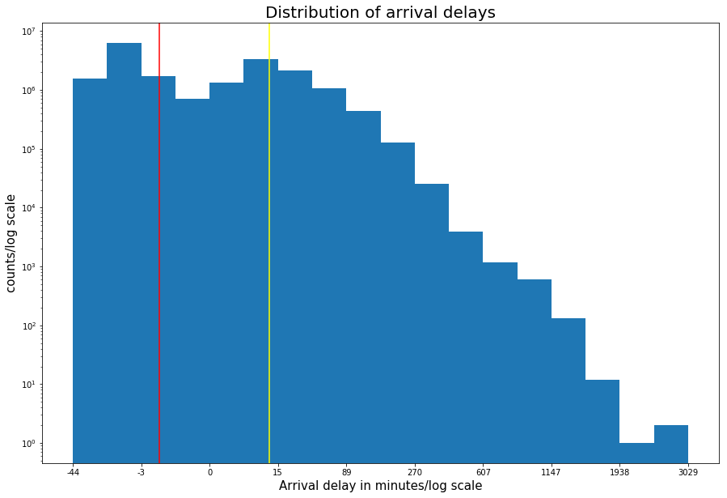

```python
# create histogram to show distribution of arrival delays
plt.figure(figsize=[15, 10])
bin_edges = np.arange(cbrt_trans(df_cct['ArrDelay'].min()),cbrt_trans(df_cct['ArrDelay'].max())+1, 1)
plt.hist(df_cct['ArrDelay'].apply(cbrt_trans), bins=bin_edges)
tic_locs = np.arange(cbrt_trans(df_cct['ArrDelay'].min()), cbrt_trans(df_cct['ArrDelay'].max())+2, 2)
plt.xticks(tic_locs, cbrt_trans(tic_locs, inverse=True).astype(int))
plt.yscale('log')
plt.ylabel('counts/log scale', fontsize=15)
plt.xlabel('Arrival delay in minutes/log scale', fontsize=15)
plt.title('Distribution of arrival delays', fontsize=20)
plt.axvline(x=-1, color='red')
plt.axvline(x=2.22, color='yellow');
```

**The next slide shows the distribution of departure delay data for U/S flights. 50 % of the data left of the red line. 75 % of the data left of the yellow line. Also for departure delays the majority of the flights is on time. Departure delay data and arrival delay data have an correlation coefficient of 0.91 and are therefore highly correlated and can be used interchangeably for conveying messages about delay data.**

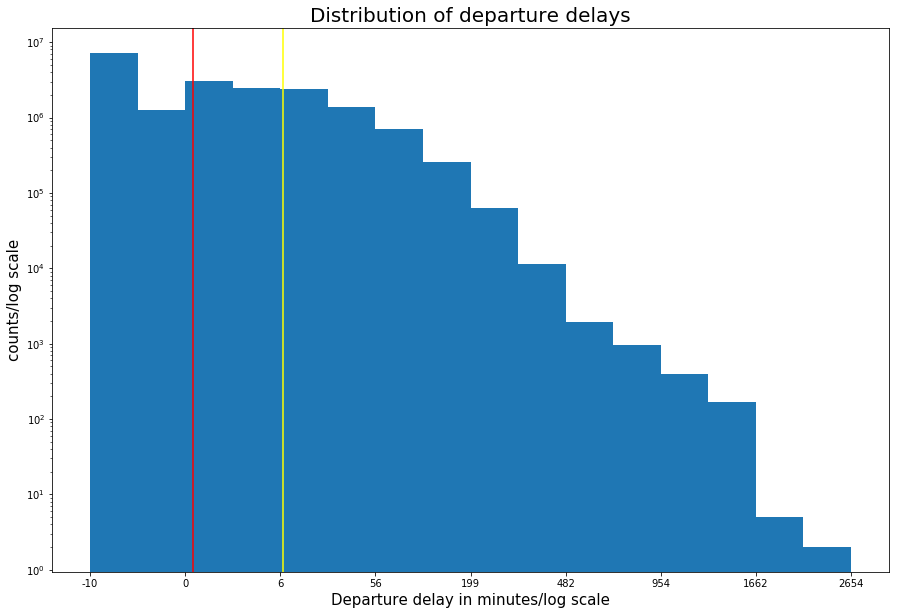

```python
# create histogram to show distribution of departure delays
plt.figure(figsize=[15,10])
bin_edges = np.arange(cbrt_trans(df_cct['DepDelay'].min()),cbrt_trans(df_cct['DepDelay'].max())+1, 1)
plt.hist(df_cct['DepDelay'].apply(cbrt_trans), bins=bin_edges)
tic_locs = np.arange(cbrt_trans(df_cct['DepDelay'].min()), cbrt_trans(df_cct['DepDelay'].max())+2, 2)
plt.xticks(tic_locs, cbrt_trans(tic_locs, inverse=True).astype(int))
plt.ylabel('counts/log scale', fontsize=15)
plt.xlabel('Departure delay in minutes/log scale', fontsize=15)
plt.title('Distribution of departure delays', fontsize=20)
plt.yscale('log')
plt.axvline(x=0, color='red')
plt.axvline(x=1.91, color='yellow');
```

**Are there differences between airlines? The next slide shows that there are no major differences between delay times of airlines. Spread is huge. Some airlines seem to manage delays more consistent than others. Only important airlines are labeled.**

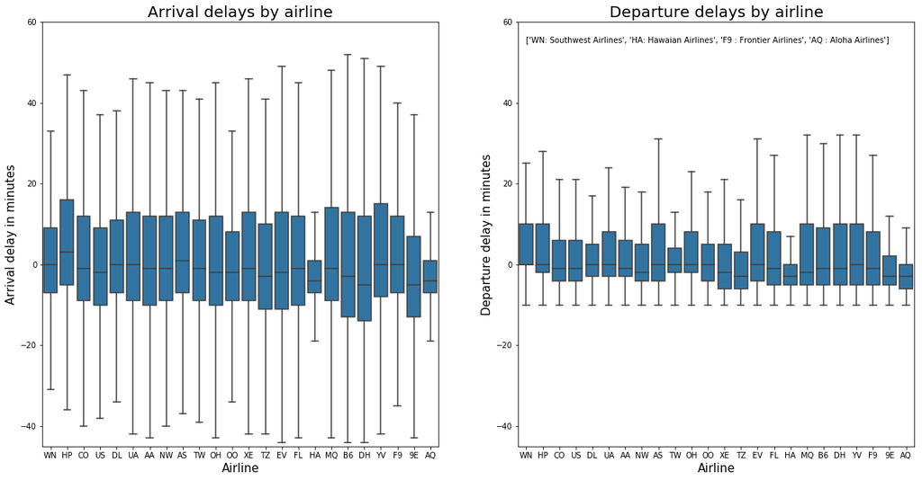

```python
# create boxplot to show differences between arrival and departure delays for airlines
plt.figure(figsize=[20, 10])
base_color = sns.color_palette()[0]
plt.subplot(1,2,1)
sns.boxplot(data=df_cct, x='UniqueCarrier', y='ArrDelay', color=base_color, showfliers=False)
plt.ylabel('Arrival delay in minutes', fontsize=15)
plt.xlabel('Airline', fontsize=15)
plt.title('Arrival delays by airline', fontsize=20)
plt.ylim(-45, 60)
plt.subplot(1,2,2)
sns.boxplot(data=df_cct, x='UniqueCarrier', y='DepDelay', color=base_color, showfliers=False)
plt.ylabel('Departure delay in minutes', fontsize=15)
plt.xlabel('Airline', fontsize=15)
plt.title('Departure delays by airline', fontsize=20)
plt.ylim(-45, 60)
plt.text(x=0, y=55,s=['WN: Southwest Airlines', 'HA: Hawaian Airlines', 'F9 : Frontier Airlines', 'AQ : Aloha Airlines']);
```

**Does this mean that all airlines are equal? Not quite the next slide shows the difference in the percentage of delayed flights. This means that there are differences in the probability that one is delayed with a specific airline between 27 and 57%. But once you are delayed the time of delay does not differ between airlines. Only relevant airlines are listed.**

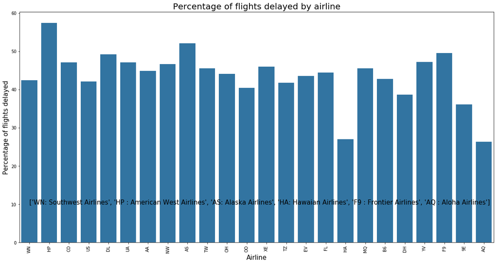

```python
# create barplot to show differences in percentages of flight delays
plt.figure(figsize=[20, 10])
base_color = sns.color_palette()[0]
sns.barplot(data=df_prop, x='UniqueCarrier', y='PercDelay',color=base_color );
plt.ylabel('Percentage of flights delayed', fontsize=15)
plt.xlabel('Airline', fontsize=15)
plt.title('Percentage of flights delayed by airline', fontsize=20)
plt.xticks(rotation=90)
plt.text(x=0, y=10,s=['WN: Southwest Airlines','HP : American West Airlines', 'AS: Alaska Airlines', 'HA: Hawaian Airlines', 'F9 : Frontier Airlines', 'AQ : Aloha Airlines'], fontsize=15);
```

**Does the distribution of distances served maybe play a role for the delayed flights? Distance was not correlated with arrival delay and departure delay in the original data. Also here the percentage of flights delayed does not correlate with the percentage of delays as can be seen for e.g. American West Airline and Frontier Airline**

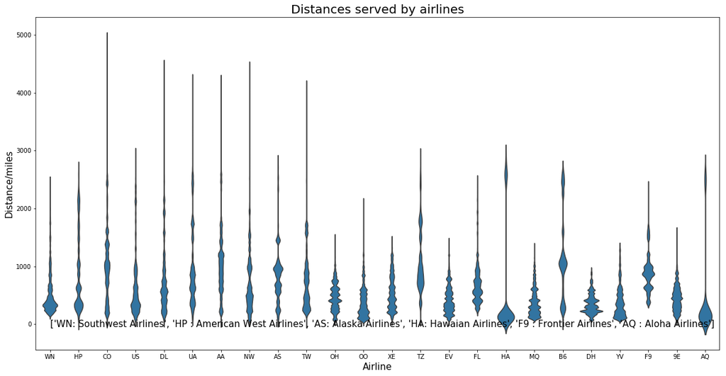

```python
# create violinplot to show distance distribution
plt.figure(figsize=[20, 10])
base_color = sns.color_palette()[0]
sns.violinplot(data=df_cct, x='UniqueCarrier', y='Distance', inner=None, color=base_color)
plt.xlabel('Airline', fontsize=15)
plt.ylabel('Distance/miles', fontsize=15)
plt.title('Distances served by airlines', fontsize=20)
plt.text(x=0, y=-50,s=['WN: Southwest Airlines','HP : American West Airlines', 'AS: Alaska Airlines', 'HA: Hawaian Airlines', 'F9 : Frontier Airlines', 'AQ : Aloha Airlines'], fontsize=15);
```

**Now what about airports? The next slide shows the percentage of delays of the 20 airports with the most delays. So you have to choose the airport and the airline wisely if you have a chance to do so.**

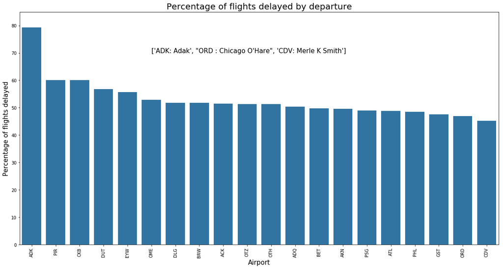

```python
# create barplot to show differences in percentage of departure delays for airports
plt.figure(figsize=[20, 10])
base_color = sns.color_palette()[0]
sns.barplot(data=df_prop_dep[:20], x='Origin', y='PercDelay', color=base_color);
plt.ylabel('Percentage of flights delayed', fontsize=15)
plt.xlabel('Airport', fontsize=15)
plt.title('Percentage of flights delayed by departure', fontsize=20)
plt.xticks(rotation=90)
plt.ylim(0, 85)
plt.text(x=5, y=70,s=['ADK: Adak',"ORD : Chicago O'Hare", 'CDV: Merle K Smith'], fontsize=15);
```

**Do airports with high frequency of delays differ in their average delay time? And do airlines in those airports have all the same delay times? Airports differ in the average delay times from 20 to 70 minutes. And even within airports different airlines have different average delay times. Also remarkable is that small airports often serving only 1 airline have a high share in the top 20 airports regarding percentage of delays.**

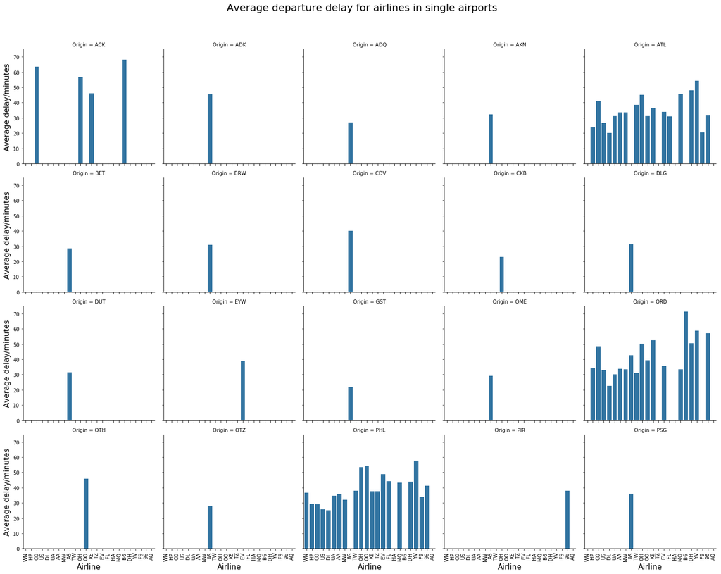

```python
# create barplots to show delay differences of airlines in different airports
gen_order =['WN', 'HP', 'CO', 'US', 'DL', 'UA', 'AA', 'NW', 'AS', 'TW', 'OH', 'OO', 'XE', 'TZ', 'EV','FL', 'HA', 'MQ', 'B6', 'DH', 'YV', 'F9', '9E', 'AQ' ]
g = sns.FacetGrid(data = df_prop1_hf_origin, col='Origin', height = 4, col_wrap=5)
g.map(sns.barplot, 'UniqueCarrier', 'Delayed', order=gen_order)
plt.subplots_adjust(top=0.9)
g.fig.suptitle('Average departure delay for airlines in single airports', fontsize=20)
g.set_ylabels('Average delay/minutes', fontsize=15)
g.set_xlabels('Airline', fontsize=15)
for ax in g.axes.flat:
    for label in ax.get_xticklabels():
        label.set_rotation(90);
```

**Is a delay a delay? Not quite in aviation. If you consider a delay as an event of leaving or arriving after the scheduled time regardless of the amount of time you have a lot of delays. In aviation however a delay is counted as a delay not until the delay is more than 15 minutes. This is the way airlines can claim 80% punctuallity. This neat little trick lowers the percentage of delayed flights by around 20 base points.**

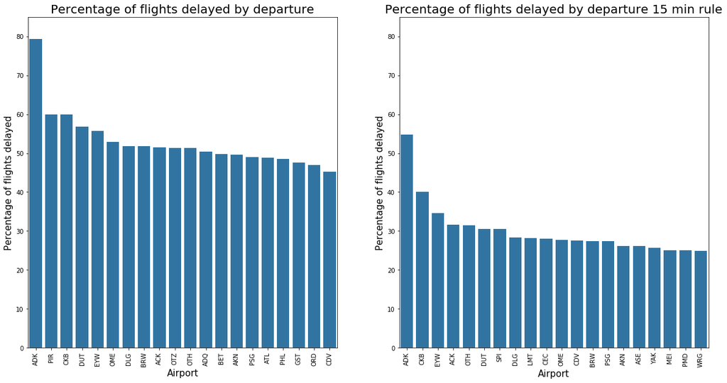

```python
# create barplot to show the difference between normal delay and 15 minutes rule
plt.figure(figsize=[20, 10])
base_color = sns.color_palette()[0]
plt.subplot(1, 2, 1)
sns.barplot(data=df_prop_dep[:20], x='Origin', y='PercDelay', color=base_color);
plt.ylabel('Percentage of flights delayed', fontsize=15)
plt.xlabel('Airport', fontsize=15)
plt.title('Percentage of flights delayed by departure', fontsize=20)
plt.xticks(rotation=90)
plt.ylim(0, 85);
plt.subplot(1, 2, 2)
sns.barplot(data=df_prop_dep_15[1:21], x='Origin', y='PercDelay', color=base_color);
plt.ylabel('Percentage of flights delayed', fontsize=15)
plt.xlabel('Airport', fontsize=15)
plt.title('Percentage of flights delayed by departure 15 min rule', fontsize=20)
plt.xticks(rotation=90)
plt.ylim(0, 85);
```

**Where to go from here**

**I did not do in depth analysis of reasons for delays. Why there is a similar value distribution for all of the different reasons for delays and why single airlines show a similar pattern for all of the delay reasons is intuitively not clear for me. I would expect a more uniform distribution of weather delays for airlines or at least statistics that are not synchronized with the statistics for late aircraft delay, carrier delay etc..I did not explore were the PUB airport suddenly appeared from etc.. Furthermore I did not dig deeper for many of the variables which I also could have used for multivariate analyses but I do think the scope of the project is fulfilled with the available data.**